# Capstone - Task 3

Sheng Xu

6/2/2020

Introduction For this task, I am using the US files as sample to demo the idea of data and file processing. I downloaded the file, and to reduce processing time, I commented the download script to avoid duplication.I used readLines function to create data set for the three US files, then use stri_stats_general function to show basic char information (lines, file sizes and so on). From there I leveraged stri_count_words function to check the word count per line. After further sampling nad cleaning up of the data set, I created a function to check the high frequency words used in the US files (combined all three into one data set).

```r
# Create a directory named Capstone, then download the file from url, and unzip it into the Capstone directory.The file is already downloaded, to increase the process efficiency, I comment it out from the script. But you could download the file by running below script.

## url <- "https://d396qusza40orc.cloudfront.net/dsscapstone/dataset/Coursera-SwiftKey.zip"
## download.file(url, destfile="./oursera-SwiftKey.zip")
## unzip(zipfile="./Coursera-SwiftKey.zip", exdir="./Capstone")
```

```r
# Use the readLines function to read data, then use stri_stats_general function to show basic char information.

blogs <- readLines("Capstone/final/en_US/en_US.blogs.txt", encoding="UTF-8")
twitter <- readLines("Capstone/final/en_US/en_US.twitter.txt", encoding="UTF-8")
news <- readLines("Capstone/final/en_US/en_US.news.txt", encoding="UTF-8")
# Use stri_stats_general function to show basic char information.

stri_stats_general(blogs)
```

```
##       Lines LinesNEmpty       Chars CharsNWhite
##      899288      899288   206824382   170389539
```

```r
stri_stats_general(twitter)
```

```
##       Lines LinesNEmpty       Chars CharsNWhite
##     2360148     2360148   162096031   134082634
```

```r
stri_stats_general(news)
```

```
##       Lines LinesNEmpty       Chars CharsNWhite
##       77259       77259    15639408    13072698
```

```r
# Now let's count how many words per line there are in each of the three files.

words_Blogs   <- stri_count_words(blogs)
words_Twitter <- stri_count_words(twitter)
words_News <- stri_count_words(news)

summary(words_Blogs)
```

```
##    Min. 1st Qu.  Median    Mean 3rd Qu.    Max.
##    0.00    9.00   28.00   41.75   60.00 6726.00
```

```r
summary(words_Twitter)
```

```
##    Min. 1st Qu.  Median    Mean 3rd Qu.    Max.
##    1.00    7.00   12.00   12.75   18.00   47.00
```

```r
summary(words_News)
```

```
##    Min. 1st Qu.  Median    Mean 3rd Qu.    Max.
##    1.00   19.00   32.00   34.62   46.00 1123.00
```

```r
# Create sub set of data, and corpus. Learn more about corpus at https://www.rdocumentation.org/packages/tm/versions/0.7-7/topics/Corpus

sample_data_blogs <- sample(blogs, size = 1000)
sample_data_news <- sample(news, size = 1000)
sample_data_twitter <- sample(twitter, size = 1000)
sample_data <- c(sample_data_blogs, sample_data_news, sample_data_twitter)
corpus_data <- VCorpus(VectorSource(sample_data))

# Clean up data and removve inrelevant words
toSpace <- content_transformer(function(x, pattern) gsub(pattern, " ", x))
corpus_data <- tm_map(corpus_data, toSpace, "/|@|//|$|:|:)|*|&|!|?|_|-|#|")
corpus_data <- tm_map(corpus_data, content_transformer(tolower))
corpus_data <- tm_map(corpus_data, removeNumbers)
corpus_data <- tm_map(corpus_data, removePunctuation)
corpus_data <- tm_map(corpus_data, removeWords, stopwords())
corpus_data <- tm_map(corpus_data, stemDocument)
corpus_data <- tm_map(corpus_data, stripWhitespace)
```

```r
# Create function to check high frequency words. Used Document Term Matrix function, to learn more about this function: https://www.rdocumentation.org/packages/tm/versions/0.7-7/topics/TermDocumentMatrix

high_freq_words <- function (corpus_data) {
    term_sparse <- DocumentTermMatrix(corpus_data)
    term_matrix <- as.matrix(term_sparse)   ## convert our term-document-matrix into a normal matrix
    freq_words <- colSums(term_matrix)
    freq_words <- as.data.frame(sort(freq_words, decreasing=TRUE))
    freq_words$word <- rownames(freq_words)
    colnames(freq_words) <- c("Frequency","word")
    return (freq_words)
}
```

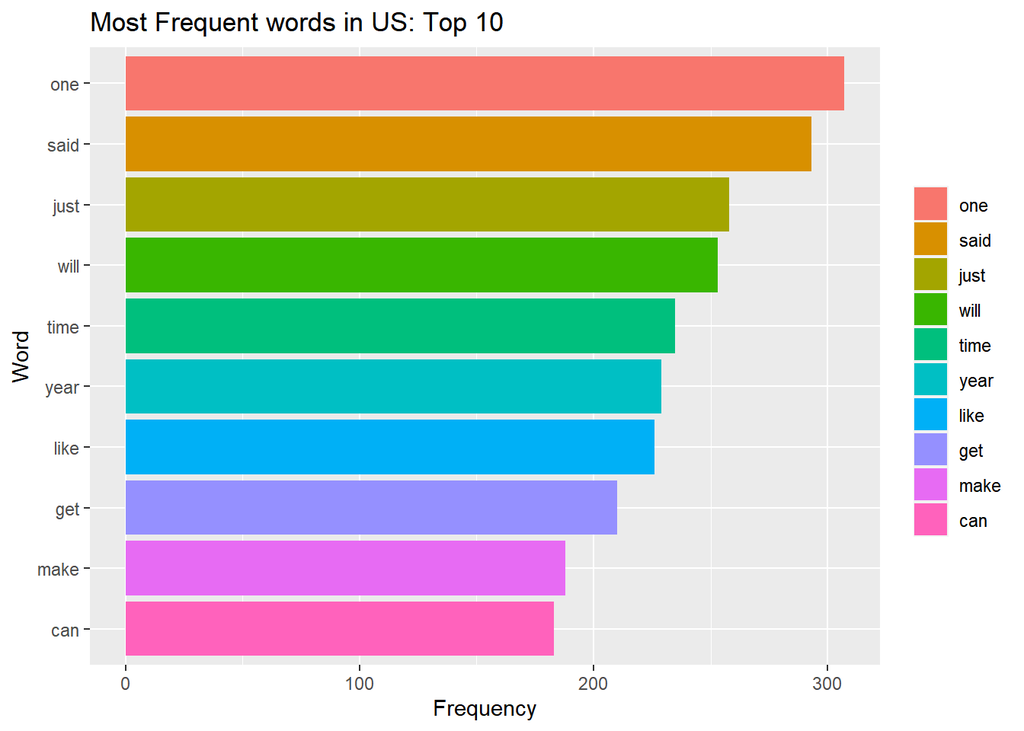

```r
# Now we can take a look at the sample data from all US files, and check the most frequently used words

    most_used_word <- high_freq_words(corpus_data)
    most_used_word_top10 <- most_used_word[1:10,]

    p<-ggplot(data=most_used_word_top10, aes(x=reorder(word,Frequency), y=Frequency,
                    fill=factor(reorder(word,-Frequency))))+ geom_bar(stat="identity")
    p + xlab("Word") +labs(title = "Most Frequent words in US: Top 10") +theme(legend.title=element_blank()) + coord_flip()
```

Next Steps For this task, I combined all three US files, so it is easier to demo the concept of file processing. For building the shiny app, I will potentially do more data comparison between different files.